# Normalization performance report

- study: SCZ combined
- author: Marta Nabais
- date: 08 October, 2019

## Parameters used to test normalization

```
## $variables
## [1] "Slide"       "sentrix_row" "sentrix_col" "Sex"         "cohort"
##
## $control.pcs
##  [1]  1  2  3  4  5  6  7  8  9 10
##
## $batch.pcs
##  [1]  1  2  3  4  5  6  7  8  9 10
##
## $batch.threshold
## [1] 0.01
##
## $colours
## NULL
```

## Control probe scree plots

The variance captured by each principal component.

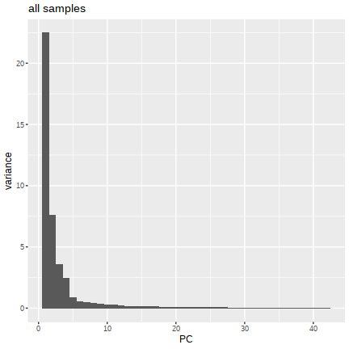

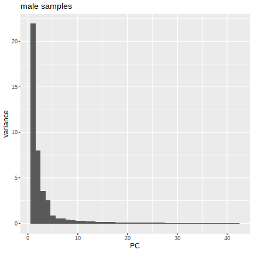

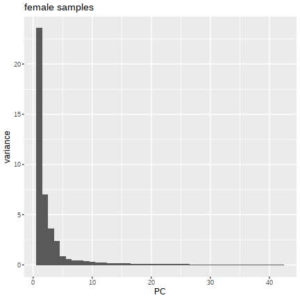

## Principal components of the control probes

The following plots show the first 3 principal components of the control matrix colored by batch variables. Batch variables with more than 10 levels are omitted.

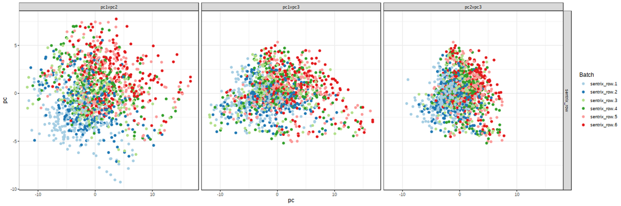

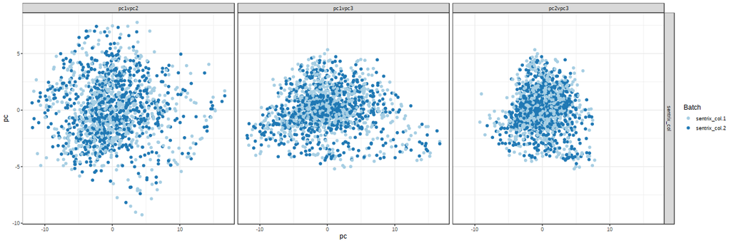

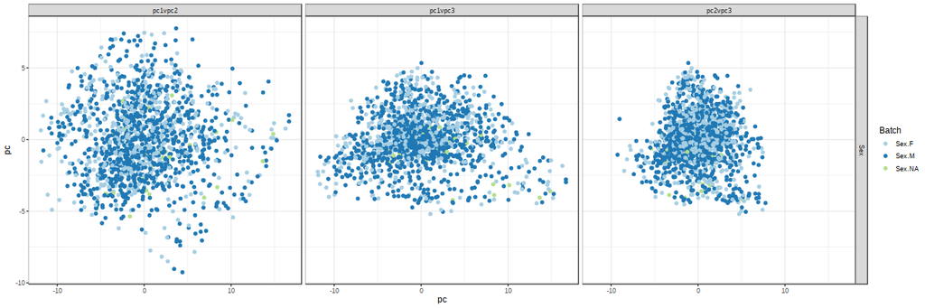

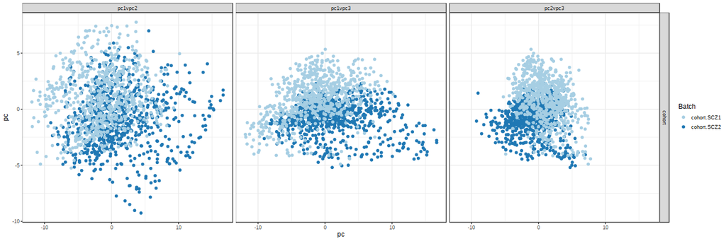

## Control probe associations with measured batch variables

Principal components of the control probes were regressed against batch variables. Shown are the \(-log_{10}\) p-values for these regressions. The horizontal dotted line denotes \(p = 0.05\) in log-scale.

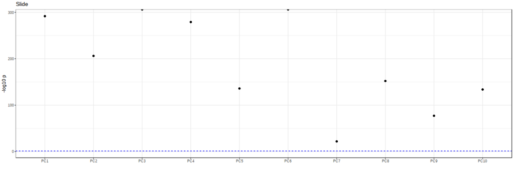

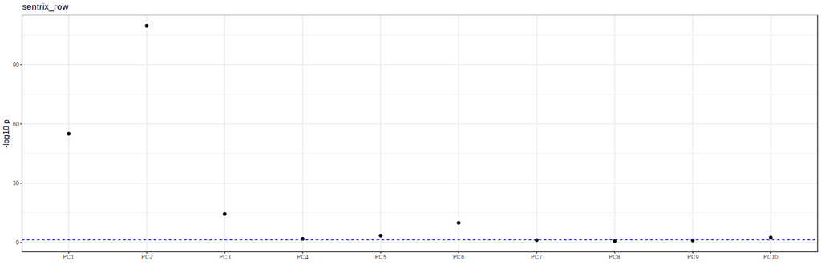

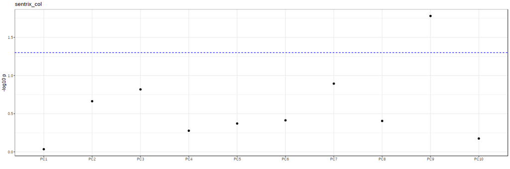

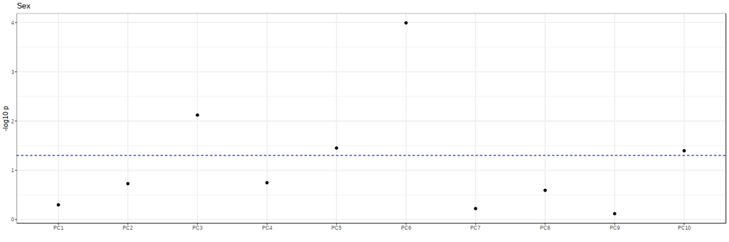

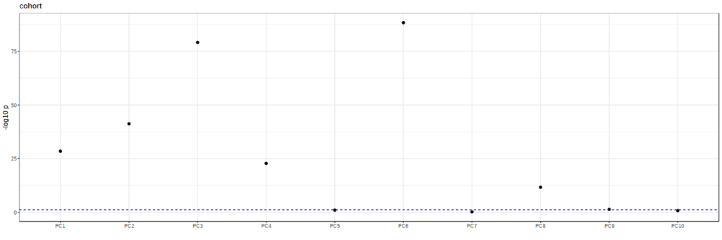

The following plots show regression coefficients when each principal component is regressed against each batch variable level along with 95% confidence intervals. Cases significantly different from zero are coloured red (p < 0.01, t-test).

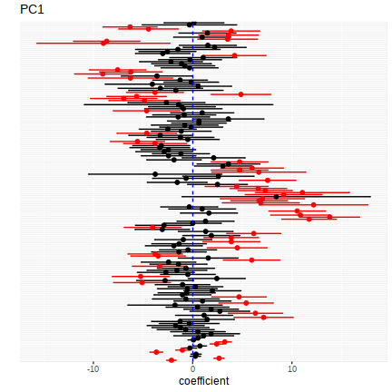

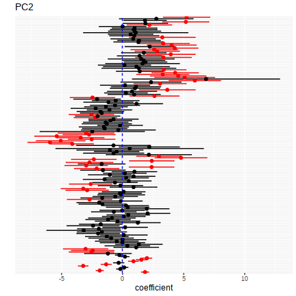

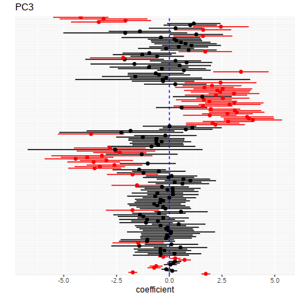

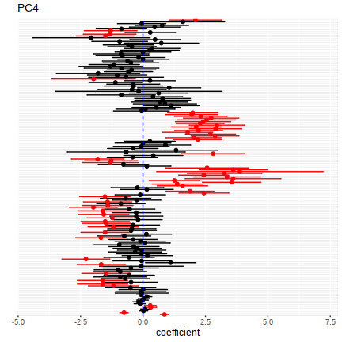

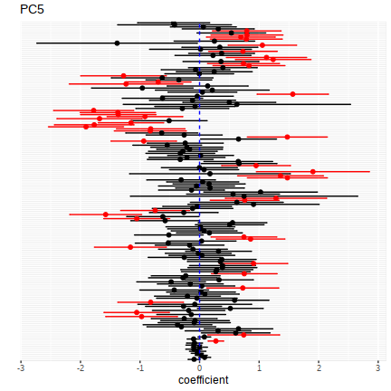

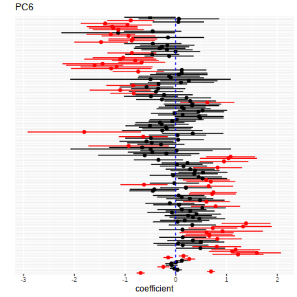

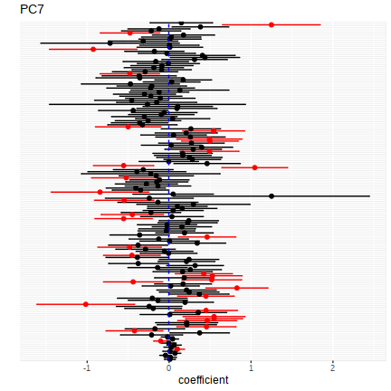

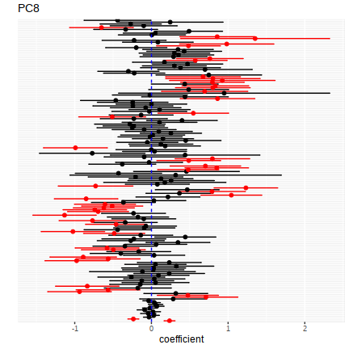

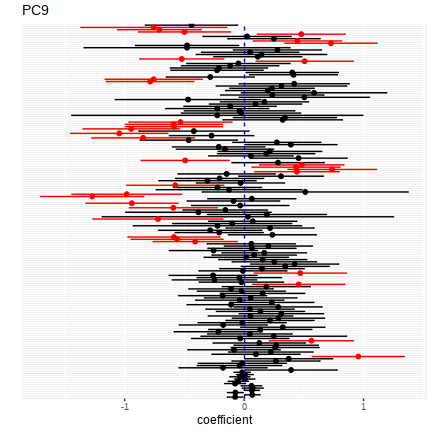

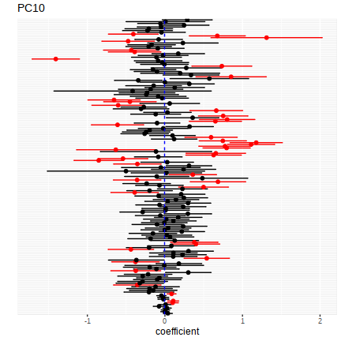

| batch.variable | batch.value | principal.component | test | p.value | estimate | lower | upper |
| --- | --- | --- | --- | --- | --- | --- | --- |
| Slide |  | PC1 | F-test | 1.93e-292 | 24.4319 |  |  |
| Slide | 3998567021 | PC1 | t-test | 6.83e-05 | -5.0976 | -7.9541 | -2.2411 |
| Slide | 3998567028 | PC1 | t-test | 4.23e-05 | -5.2403 | -8.0960 | -2.3847 |
| Slide | 3998567064 | PC1 | t-test | 6.77e-03 | -3.3250 | -6.0689 | -0.5811 |
| Slide | 3998567086 | PC1 | t-test | 3.27e-06 | 5.9502 | 3.0995 | 8.8010 |
| Slide | 3998568009 | PC1 | t-test | 4.53e-03 | -3.4852 | -6.2284 | -0.7420 |
| Slide | 3998568010 | PC1 | t-test | 2.13e-03 | -3.7701 | -6.5120 | -1.0282 |
| Slide | 3998568018 | PC1 | t-test | 8.20e-04 | 4.4943 | 1.4945 | 7.4941 |
| Slide | 3998568054 | PC1 | t-test | 2.38e-03 | 3.8931 | 1.0300 | 6.7561 |
| Slide | 3998609023 | PC1 | t-test | 1.54e-03 | 3.8869 | 1.1455 | 6.6282 |
| Slide | 3998609041 | PC1 | t-test | 4.91e-07 | 6.1567 | 3.4299 | 8.8835 |
| Slide | 3998634014 | PC1 | t-test | 1.68e-03 | -4.0262 | -6.8886 | -1.1637 |
| Slide | 3998928013 | PC1 | t-test | 3.65e-21 | 11.7286 | 8.9918 | 14.4653 |
| Slide | 3998928014 | PC1 | t-test | 4.22e-24 | 13.8166 | 10.8173 | 16.8159 |
| Slide | 3998928042 | PC1 | t-test | 8.64e-16 | 10.8526 | 7.8677 | 13.8376 |
| Slide | 3998928122 | PC1 | t-test | 3.03e-16 | 10.5325 | 7.6817 | 13.3833 |
| Slide | 3998998017 | PC1 | t-test | 6.89e-07 | 12.1840 | 6.7145 | 17.6535 |
| Slide | 3998998022 | PC1 | t-test | 7.59e-05 | 6.8631 | 2.9921 | 10.7342 |
| Slide | 3998998037 | PC1 | t-test | 1.71e-07 | 6.6957 | 3.8436 | 9.5478 |
| Slide | 3998998038 | PC1 | t-test | 2.09e-04 | 7.0272 | 2.7954 | 11.2590 |
| Slide | 3998998070 | PC1 | t-test | 1.33e-07 | 9.1634 | 5.2942 | 13.0325 |
| Slide | 3998998100 | PC1 | t-test | 2.03e-07 | 11.0570 | 6.3171 | 15.7969 |
| Slide | 3999215187 | PC1 | t-test | 2.76e-09 | 7.3008 | 4.5698 | 10.0319 |
| Slide | 3999215189 | PC1 | t-test | 2.29e-07 | 6.6110 | 3.7653 | 9.4567 |
| Slide | 3999215192 | PC1 | t-test | 1.77e-03 | 4.4261 | 1.2635 | 7.5887 |
| Slide | 3999215213 | PC1 | t-test | 3.96e-09 | 7.5487 | 4.6960 | 10.4014 |
| Slide | 9721367113 | PC1 | t-test | 1.67e-03 | 6.6635 | 1.9274 | 11.3996 |
| Slide | 9741779020 | PC1 | t-test | 2.19e-04 | 4.7335 | 1.8748 | 7.5922 |
| Slide | 9741779024 | PC1 | t-test | 2.27e-05 | 5.9890 | 2.8353 | 9.1426 |
| Slide | 9769100109 | PC1 | t-test | 2.22e-04 | 4.7291 | 1.8704 | 7.5878 |

[output cut: 492 more lines]

## Principal components of the normalized betas

The following plots show the first 3 principal components of the most variable probes colored by batch variables. Batch variables with more than 10 levels are omitted.

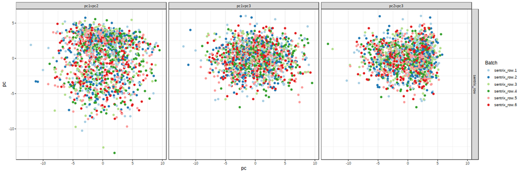

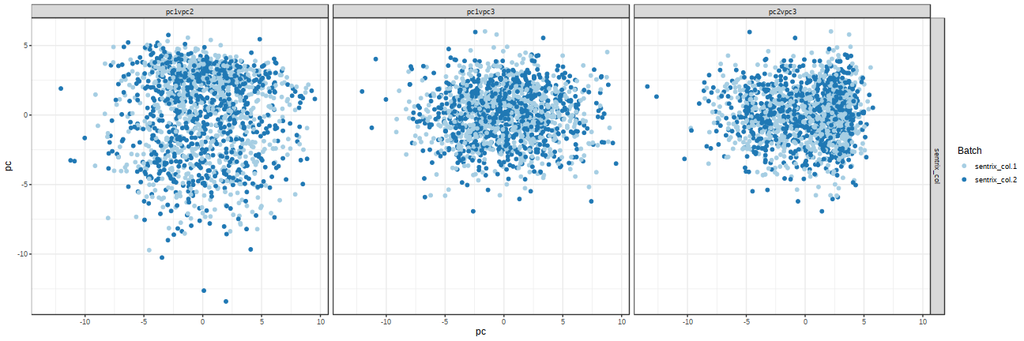

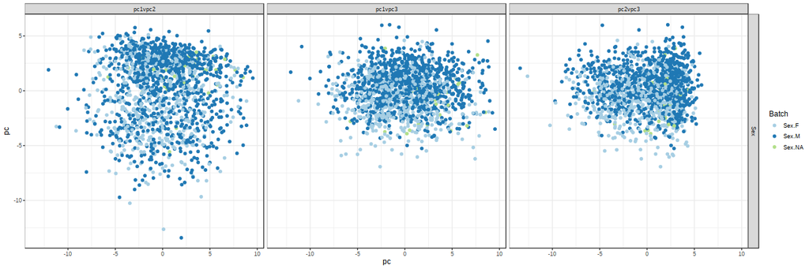

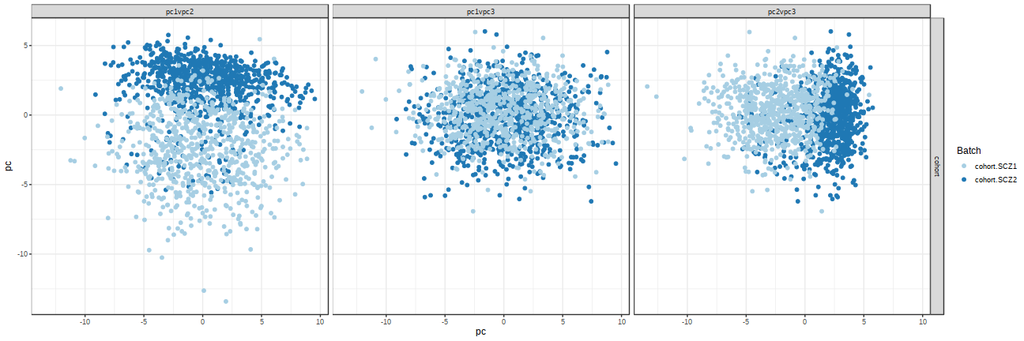